```r
library(tidyverse)
library(knitr)
set.seed(5458)
```

### 4. Modelos jerárquicos y evaluación de ajuste

**Postestratificación** es un método estándar que se utiliza para corregir las estimaciones obtenidas de muestreo probabilístico cuando hay distintas probabilidades de selección y para corregir no respuesta. A grandes rasgos, se divide la población en categorías y se estima la distribución de las respuestas en cada categoría, después se pondera cada categoría de acuerdo a su tamaño en la población. Típicamente las categorías se crean con variables demográficas (sexo, edad, …).

La dificultad que suele surgir en el proceso de postestratificación es que por una parte se desea crear las celdas lo más finas posible, considerando el cruce de muchas variables, con el objetivo de corregir en mayor medida posibles sesgos en las estimaciones; sin embargo, conforme aumenta el número de celdas el número de respondentes en cada una disminuye (muchas incluso quedan vacías) y esto conlleva a que las estimaciones dentro de cada celda sean poco precisas. Ante esta dificultad, la propuesta de MRP es modelar las respuestas condicional a las variables de postestratificación, cuando las categorías de la postestratificación siguen de manera natural estructuras jerárquicas (como hogares en estados) se puede mejorar la eficiencia de la estimación ajustando modelos multinivel.

Es así que MRP es una extensión a los ajustes de postestratificación clásicos que permite usar más categorías y por tanto información más detallada de la población. Una ventaja adicional es que además hace posible estimar la respuesta en subcategorias demográficas o geográficas. En este ejercicio reproduciremos el modelo que se ajusta en @parkgelmanbafumi lo puedes descargar de [esta liga](http://www.stat.columbia.edu/~gelman/research/published/parkgelmanbafumi.pdf).

En esta aplicación se utilizan encuestas de opinión pública en EUA, en particular modelamos la probabilidad de que un respondente prefiera al candidato Republicano como presidente y usando los datos de encuestas de *CBS News* levantadas previo a la elección presidencial de 1988.

Ahora, definimos el modelo multinivel a usar, usaremos regresión logística multinivel, en este planteamiento la variable $y_i$ indica si la $i$-ésima persona apoyaba al candidato republicano o no, y se agregan todas las variables demográficas como covariables.

$$\begin{aligned}
P(y_i = 1) &= logit^{-1}(\beta^0 + \beta^{mujer}\cdot mujer_i + \beta^{neg}\cdot neg_i+\beta^{mujer, neg}\cdot mujer_i \cdot neg_i+ \\
& \beta_{edad(i)}^{edad} + \beta_{edad(i), edu(i)}^{edad,edu} +
\beta_{estado(i)}^{estado})
\end{aligned}$$

En este ejemplo la estructura multinivel se reduce al coeficiente de estado que se modela con indicadoras de región y una medida del apoyo Republicano en el estado reportado en la elección previa.

$$\beta_{j}\sim N(\beta_{region(j)}^{region}+\beta^{vprev}\cdot vprev_j, \sigma^2_{estado})$$

Ajustaremos este modelo usando el programa JAGS (Just Another Gibbs Sampler), y utilizamos las estimaciones para hacer predicciones a nivel estado ($\theta_s$):

$$\theta_s=\frac{\sum_{j \in s}N_{j}\pi_j}{\sum_{j \in s}N_{j}}$$

donde $N_j$ indica el número de individuos en cada estado que pertenecen a la $j$-ésima celda, la información para determinar las $N_j$ se obtendrá del censo de población.

### Implementación

Datos en [election88](http://www.stat.columbia.edu/~gelman/arm/examples/election88/), o en la carpeta data.

```r
# preparación de los datos
library(haven)
library(R2jags)
# datos de encuestas
polls <- read_dta("data/polls.dta")
# nos quedamos con la última encuesta y eliminamos faltantes
last_poll <- polls %>%
  filter(survey == 8) %>%
  na.omit()
# datos de elecciones pasadas para utilizar como covariable y variable región
presvote <- read_dta("data/presvote.dta") %>%
  cbind(region = c(3,4,4,3,4,4,1,1,5,3,3,4,4,2,2,2,2,3,3,1,1,1,2,2,3,2,4,2,4,
                   1,1,4,1,3,2,2,3,4,1,1,3,2,3,3,4,1,3,4,1,2,4))
```

Los datos para el modelo serán:

```r
data_jags <- list(n = nrow(last_poll),
                  n_region = 5,
                  n_age = n_distinct(last_poll$age),
                  n_edu = n_distinct(last_poll$edu),
                  n_state = max(last_poll$state),
                  y = last_poll$bush,
                  female = last_poll$female,
                  edu = last_poll$edu,
                  age = last_poll$age,
                  black = last_poll$black,
                  state = last_poll$state,
                  v_prev = presvote$g76_84pr,
                  region = presvote$region
)
```

Y el código en JAGS:

```r
model_mrp <- "
    model {
        for (i in 1:n){
            y[i] ~ dbern(p_bound[i])
            p_bound[i] <- max(0, p[i])
            p[i] <- ilogit(b_0 + b_female*female[i] + b_black * black[i] +
                b_female_black * female[i]*black[i] +
                a_age[age[i]] + a_edu[edu[i]] + a_age_edu[age[i],edu[i]] +
                a_state[state[i]])
    }
    b_0 ~ dnorm (0, .0001)
    b_female ~ dnorm (0, .0001)
    b_black ~ dnorm (0, .0001)
    b_female_black ~ dnorm (0, .0001)
    for (j in 1:n_age) {
        a_age[j] ~ dnorm(0, tau_age)}
    for (j in 1:n_edu) {
        a_edu[j] ~ dnorm(0, tau_edu)}
    for (j in 1:n_age) {
        for (k in 1:n_edu){
            a_age_edu[j,k] ~ dnorm(0, tau_age_edu)
        }
    }
    for (j in 1:n_state) {
        a_state[j] ~ dnorm(a_state_hat[j], tau_state)
        a_state_hat[j] <- a_region[region[j]] + b_v_prev*v_prev[j]
    }
    b_v_prev ~ dnorm (0, .0001)
    for (j in 1:n_region) {
        a_region[j] ~ dnorm(0, tau_region)
    }
    tau_age <- pow(sigma_age, -2)
    tau_edu <- pow(sigma_edu, -2)
    tau_age_edu <- pow(sigma_age_edu, -2)
    tau_state <- pow(sigma_state, -2)
    tau_region <- pow(sigma_region, -2)
    sigma_age ~ dunif (0, 100)
    sigma_edu ~ dunif (0, 100)
    sigma_age_edu ~ dunif (0, 100)
    sigma_state ~ dunif (0, 100)
    sigma_region ~ dunif (0, 100)
    }
    "
cat(model_mrp, file = 'model_mrp.bugs')
```

1. **Modelo**. Ajusta el modelo y revisa convergencia, describe cuantas cadenas, iteraciones y etapa de calentamiento elegiste, además escribe como determinaste convergencia.

Agregamos la variable *fem_black* para tener un modelo de los valores iniciales.

```r
last_poll <- last_poll %>% mutate("fem_black"=last_poll$female*last_poll$black) %>%
  select(-c("year", "survey", "org"))
```

Generamos los valores iniciales de forma aleatoria. Estos van a provenir de un modelo parecido al que se busca, el modelo se calcula a partir de una muestra de los dato.

```r
# Definimos la función para generar valores inciales
init_theta <- function(){
  # Creamos una muestra aleatoria con reemplazo.
  muestra <- sample(1:2015, 2015, replace = TRUE)
  x_s     <- last_poll[muestra,]
  ageCat  <- unique(last_poll$age)[order(unique(last_poll$age))]
  eduCat  <- unique(last_poll$edu)[order(unique(last_poll$edu))]
  # Hacemos un modelo con regresión logística para darle un valor inicial
  # a los coeficientes
  model   <- glm(bush~., data = x_s, family = binomial(link = "logit"))
  Coefs   <- model$coefficients
  # Los coeficientes con distintos estratos como age y edu, les asignamos =
  # el valor del coeficiente dividido entre el valor de la categorìa.
  # Para la variable de state repetimos el mismo coeficiente para cada estado.
  # Para la categoría age_edu obtuvimos una matriz multiplicando el vector
  # de coeficientes asignados para edad contra el transpuesto de los asignados
  # para educación.
  # Para la inical de las varianzas ocupamos una uniforme que toma valores entre 0 y 100.

 list(b_0=Coefs[1], b_female =Coefs[5], b_black=Coefs[6],
       b_female_black=Coefs[8], a_age = Coefs[4]/ageCat,#
       a_edu = Coefs[3]/eduCat,
       a_age_edu=Coefs[4]/ageCat%*%t(Coefs[3]/eduCat),
       a_state=rep(Coefs[2],51),
       sigma_age=runif(1,0,100), sigma_edu =runif(1,0,100),
       sigma_age_edu=runif(1,0,100), sigma_state=runif(1,0,100),
       sigma_region =runif(1,0,100))
}
```

Corremos el modelo en JAGS para $10,000$ simulaciones con $2,000$ iteraciones de calentamiento para 4 cadenas con thin igual a 4.

```r
set.seed(12454)
jags_fit <- jags(
  model.file = "model_mrp.bugs",    # modelo de JAGS
  inits = init_theta,   # valores iniciales
  data = data_jags,    # lista con los datos
  parameters.to.save = c("b_0", "b_female", "b_black", "b_female_black",
                         "a_age", "a_edu", "a_age_edu", "a_state",
                         "sigma_age", "sigma_edu", "sigma_age_edu",
                         "sigma_state", "sigma_region"),  # parámetros por guardar
  n.chains = 4,   # número de cadenas
  n.iter = 10000,    # número de pasos
  n.burnin = 2000,   # calentamiento de la cadena
  n.thin = 4
)
```

```
## module glm loaded
```

Mostramos los valores para los parámentros obtenidos con JAGS.

```r
jags_fit
```

```
## Inference for Bugs model at "model_mrp.bugs", fit using jags,
##  4 chains, each with 10000 iterations (first 2000 discarded), n.thin = 4
##  n.sims = 8000 iterations saved
##                 mu.vect sd.vect     2.5%      25%      50%      75%
## a_age[1]          0.068   0.168   -0.276   -0.008    0.049    0.144
## a_age[2]         -0.075   0.171   -0.510   -0.134   -0.045    0.007
## a_age[3]          0.030   0.166   -0.342   -0.030    0.020    0.103
## a_age[4]         -0.061   0.175   -0.484   -0.125   -0.029    0.022
## a_age_edu[1,1]   -0.040   0.150   -0.400   -0.104   -0.016    0.034
## a_age_edu[2,1]    0.069   0.158   -0.198   -0.014    0.037    0.138
## a_age_edu[3,1]    0.020   0.139   -0.268   -0.045    0.009    0.083
## a_age_edu[4,1]   -0.159   0.194   -0.655   -0.261   -0.101   -0.014
## a_age_edu[1,2]    0.067   0.131   -0.156   -0.009    0.040    0.134
## a_age_edu[2,2]   -0.094   0.135   -0.409   -0.167   -0.065   -0.002
## a_age_edu[3,2]    0.012   0.121   -0.240   -0.048    0.006    0.071
## a_age_edu[4,2]   -0.009   0.132   -0.298   -0.069   -0.003    0.052
## a_age_edu[1,3]    0.051   0.140   -0.196   -0.023    0.024    0.116
## a_age_edu[2,3]   -0.012   0.126   -0.289   -0.071   -0.004    0.052
## a_age_edu[3,3]    0.010   0.132   -0.261   -0.054    0.003    0.069
## a_age_edu[4,3]    0.057   0.150   -0.204   -0.023    0.029    0.121
## a_age_edu[1,4]    0.000   0.129   -0.272   -0.062    0.000    0.061
## a_age_edu[2,4]   -0.035   0.121   -0.323   -0.094   -0.017    0.029
## a_age_edu[3,4]   -0.004   0.128   -0.279   -0.066   -0.001    0.055
## a_age_edu[4,4]    0.049   0.142   -0.208   -0.025    0.025    0.114
## a_edu[1]         -0.157   0.231   -0.711   -0.260   -0.118   -0.015
## a_edu[2]         -0.029   0.204   -0.450   -0.114   -0.016    0.061
## a_edu[3]          0.154   0.216   -0.214    0.025    0.133    0.261
## a_edu[4]          0.010   0.203   -0.392   -0.074    0.006    0.098
## a_state[1]        3.040   0.881    1.207    2.416    3.112    3.700
## a_state[2]        2.791   0.999    0.693    2.123    2.910    3.520
## a_state[3]        2.776   0.948    0.748    2.121    2.886    3.475
## a_state[4]        2.656   0.838    0.898    2.071    2.750    3.263
## a_state[5]        2.356   0.864    0.508    1.771    2.464    2.997
## a_state[6]        2.527   0.920    0.592    1.913    2.638    3.194
## a_state[7]        2.442   0.932    0.485    1.788    2.556    3.116
## a_state[8]        2.157   0.902    0.257    1.542    2.263    2.816
## a_state[9]        0.615   0.834   -1.275    0.231    0.653    1.074
## a_state[10]       2.867   0.893    0.957    2.261    2.992    3.530
## a_state[11]       2.670   0.814    1.004    2.108    2.740    3.270
## a_state[12]       2.100   0.811    0.391    1.556    2.184    2.667
```

[output cut: 127 more lines]

```
## b_female          0.106 1.001  5000
## b_female_black    0.692 1.001  3800
## sigma_age         0.852 1.012   250
## sigma_age_edu     0.356 1.026   350
## sigma_edu         1.110 1.011   260
## sigma_region      2.184 1.002  8000
## sigma_state       0.391 1.016   250
## deviance       2628.156 1.009   310
##
## For each parameter, n.eff is a crude measure of effective sample size,
## and Rhat is the potential scale reduction factor (at convergence, Rhat=1).
##
## DIC info (using the rule, pD = var(deviance)/2)
## pD = 51.6 and DIC = 2658.9
## DIC is an estimate of expected predictive error (lower deviance is better).
```

Ahora mostramos los valores de forma gráfica para determinar convergencia.

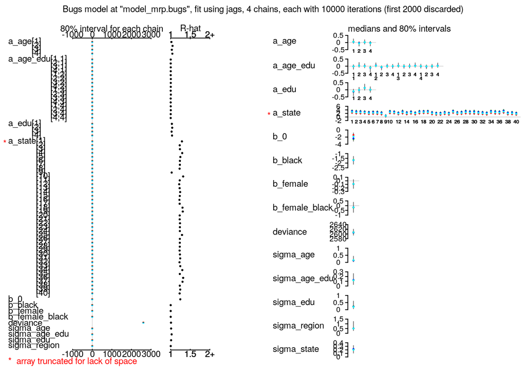

```r
plot(jags_fit)
```

2. **Evaluación de ajuste**. Usaremos la distribución predictiva posterior para simular del modelo y comparar con los datos observados. En particular veremos como se comparan las simulaciones del modelo por estado, la gráfica con lo$s datos será la que sigue:

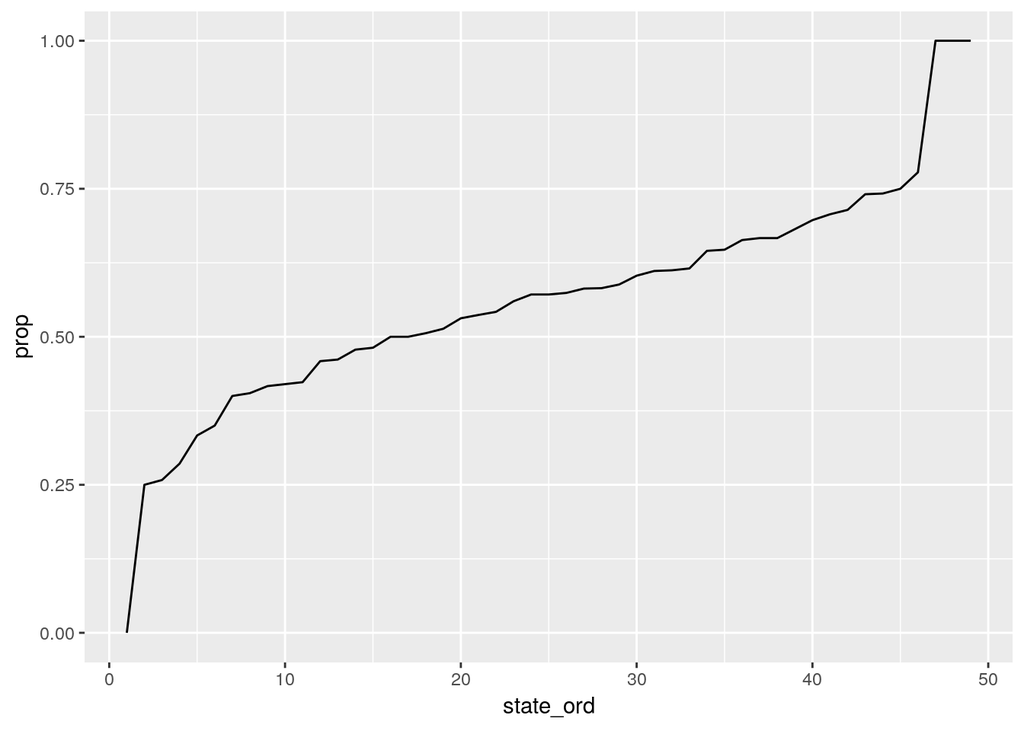

```r
bush_state <- last_poll %>%
  group_by(state) %>%
  summarise(prop = mean(bush, na.rm = TRUE)) %>%
  ungroup() %>%
  mutate(state_ord = as.numeric(reorder(state, prop)))
ggplot(bush_state, aes(x = state_ord, y = prop)) +
  geom_line()
```

Debes simular del modelo 10 conjutos de datos del tamaño de los originales (replicaciones de los datos) y hacer una gráfica de páneles donde muestres los datos originales y las replicaciones, ¿que concluyes al ver la gráfica?

Obtenemos las variables necesarias para evaluar el modelo a partir de la estimación promedio de los parámetros.

```r
# Obtener las simulaciones de las variables del modelo
Vars <- c("b_0", "b_female", "b_black", "b_female_black",
          "a_age", "a_edu", "a_age_edu", "a_state")

for (i  in Vars) {
  assign(i, jags_fit$BUGSoutput$mean[[i]])
}
```

Primero generamos replicaciones de los datos.

```r
# Replicaciones de los datos
for (i in 1:10) {
  muestra <- sample(1:2015, 2015, replace = TRUE)
  muestra <- last_poll[muestra,]
  assign(paste0("muestra_",i),muestra)
}
```

Obtenemos la predicción para las 10 muestras de los datos a partir del promedio de los parámetros según el modelo de JAGS.

```r
# Evaluación del modelo
Nsims    <- length(b_0)
invLogit <- function(x){exp(x)/(1+exp(x))}

for (i in 1:10) {
  muestra <- get(paste0("muestra_",i))
  nparam  <- sample(1:Nsims,1)
  muestra <- muestra %>% mutate("bush_pred"= b_0+ b_female*female +
                                  b_black * black +
                                  b_female_black * female*black +
                                  a_age[age] + a_edu[edu] +
                                  a_state[state])
  aux <- c()
  for (j in 1:2015) {
    aux <- c(aux,
             rbinom(1,1, invLogit(muestra$bush_pred[j] +
                                    a_age_edu[muestra$age[j] , muestra$edu[j]])))
  }
  muestra$bush_pred <- aux
  assign(paste0("muestra_",i), muestra)
  bush_state_i  <- muestra %>% group_by(state) %>%
    summarise(prop = mean(bush_pred, na.rm = TRUE)) %>%
    ungroup() %>%
    mutate(state_ord = as.numeric(reorder(state, prop))) %>%
    mutate("sim"=i)
  assign(paste0("bush_state_",i), bush_state_i)
}
```

Obtenemos la proporción estimada de votos para Bush por estado para cada una de las diez muestras.

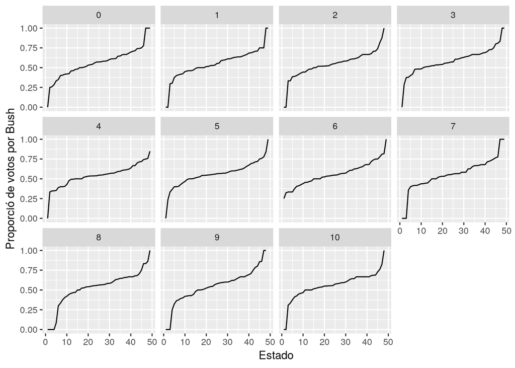

```r
bush_state_sims <- rbind(cbind(bush_state, "sim"=0),
                         bush_state_1, bush_state_2, bush_state_3,
                         bush_state_4, bush_state_5, bush_state_6,
                         bush_state_7, bush_state_8, bush_state_9,
                         bush_state_10)

ggplot(bush_state_sims, aes(x = state_ord, y = prop)) +
  geom_line()+
  facet_wrap(~ sim)+
  xlab("Estado")+ ylab("Proporció de votos por Bush")
```

3. El siguiente código predice para cada celda de la tabla del censo, vale la pena notar, que para cada celda tenemos una lista en el vector `pred` con las simuaciones que le corresponden.

```r
# construct the n.sims x 3264 matrix
census88 <- read_dta("data/census88.dta")
glimpse(census88)
```

```
## Observations: 3,264
## Variables: 6
## $ female <dbl> 0, 0, 1, 1, 0, 0, 1, 1, 0, 0, 1, 1, 0, 0, 1, 1, 0, 0, 1...
## $ black  <dbl> 0, 1, 0, 1, 0, 1, 0, 1, 0, 1, 0, 1, 0, 1, 0, 1, 0, 1, 0...
## $ age    <dbl> 1, 1, 1, 1, 2, 2, 2, 2, 3, 3, 3, 3, 4, 4, 4, 4, 1, 1, 1...
## $ edu    <dbl> 1, 1, 1, 1, 1, 1, 1, 1, 1, 1, 1, 1, 1, 1, 1, 1, 2, 2, 2...
## $ state  <dbl> 1, 1, 1, 1, 1, 1, 1, 1, 1, 1, 1, 1, 1, 1, 1, 1, 1, 1, 1...
## $ N      <dbl> 66177, 32465, 59778, 27416, 83032, 30201, 50956, 30975,...
```

```r
coef_sims <- jags_fit$BUGSoutput$sims.matrix
pred_cell <- census88 %>%
  rowwise() %>%
  mutate(
    pred = list(invLogit(coef_sims[, "b_0"] +
                           coef_sims[, "b_female"] * female +
                           coef_sims[, "b_black"] * black +
                           coef_sims[, "b_female_black"] * female * black +
                           coef_sims[, str_c("a_age[", round(age), "]")] +
                           coef_sims[, str_c("a_edu[", round(edu), "]")] +
                           coef_sims[, str_c("a_age_edu[", round(age), ",", round(edu), "]")] +
                           coef_sims[, str_c("a_state[", round(state), "]")])))
```

Para hacer las estimaciones por estado hace falta ponderar por el número de casos en cada celda:

$$\theta_s=\frac{\sum_{j \in s}N_{j}\pi_j}{\sum_{j \in s}N_{j}}$$
Evaluamos el estimador $\theta_s$ para cada simulación de los parámetros.

```r
# La función Expand la obtuvimos de:
# https://stackoverflow.com/questions/15930880/unlist-all-list-elements-in-a-dataframe
# y sirve para convertir los elementos de la lista en observaciones de la base
# para cada variable que contiene listas
Expand <- function(data) {
  ListCols <- sapply(data, is.list)
  cbind(data[!ListCols], t(apply(data[ListCols], 1, unlist)))
}
# Obtenemos la predicción por estado para cada simulación considerando
# la ponderación correspondiente.
PredSims_state <- Expand(pred_cell) %>%
  gather("sims", "preds", pred1:pred8000) %>%
  group_by(state, sims) %>%
  summarise("preds"=sum(N*preds)/sum(N))
```

4. Genera las simulaciones de $\theta_s$, recuerda que debarás calcular una simulación de cada $\theta_s$ por cada simulación de $\pi__j$ obtenida con el código de arriba. Realiza una gráfica con intervalos de credibilidad del 95% para cada $theta_s$.

Con las estimaciones obtenidas previamente calculamos el promedio y el valor en los cuantiles $0.025$ y $0.975$.

```r
# Obtenemos los valores de la media y de los cuantiles 0.025 y 0.975
# para generar intervalos de confianza al $95%$
CI_Sims_state <- PredSims_state %>%  ungroup() %>%
  group_by(state) %>%
  summarise("mean"=mean(preds), "LB"=quantile(preds,0.025), "UB"=quantile(preds, 0.975))

glimpse(CI_Sims_state)
```

```
## Observations: 51
## Variables: 4
## $ state <dbl> 1, 2, 3, 4, 5, 6, 7, 8, 9, 10, 11, 12, 13, 14, 15, 16, 1...
## $ mean  <dbl> 0.6130078, 0.6466762, 0.6447037, 0.5652377, 0.5323290, 0...
## $ LB    <dbl> 0.52544345, 0.51307080, 0.54342451, 0.44936214, 0.472287...
## $ UB    <dbl> 0.7140567, 0.7703174, 0.7444707, 0.6662861, 0.5913235, 0...
```

Ahora graficamos las estimaciones con sus respectivos intervalos de confianza.

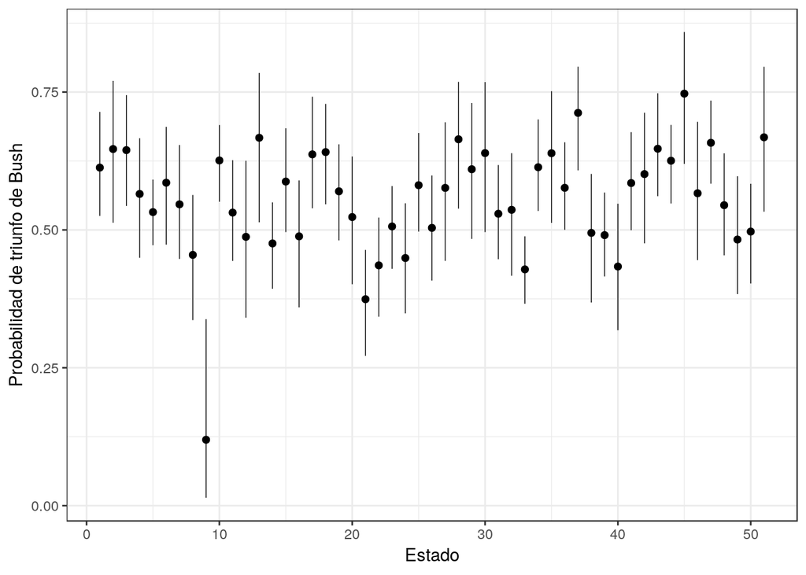

```r
# Graficamos los intervalos de confianza
ggplot(CI_Sims_state)+theme_bw()+
  geom_point(aes(state, mean), col="black")+
  geom_pointrange(aes(state, y=mean, ymin = LB, ymax = UB), size = 0.25)+
  xlab("Estado")+ylab("Probabilidad de triunfo de Bush")
```